# Background Radiation

Information & Interaction Design

Mick McQuaid

mcq@utexas.edu

University of Texas at Austin

29 Aug 2026

# Day THREE

# Background Radiation

This expression is borrowed from physics, where it refers to the radiation left over from the Big Bang. It is omnipresent and physicists have to take it into consideration when they get down to work on specific topics. Our background radiation in UX includes a bestselling book, design thinking, roles, influential people, the UX design community, and their tools and most frequently discussed issues.

## The Least Common Denominator

[figure not shown]

## Design Thinking through the Ages

[figure not shown]

## Design Thinking Steps

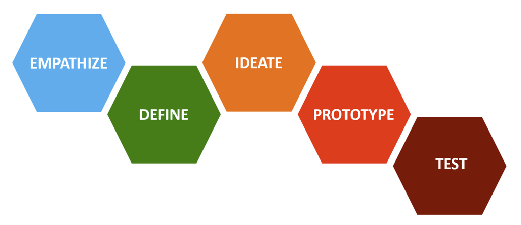

## Roles

[figure not shown]

Figure 1

## Charting an example learning journey

[figure not shown]

Figure 2

# People

## Rudolph Arnheim

Major definer of artistic principles via his most famous book, *Art and visual perception*, Arnheim (1974). His most important principle is perhaps directed tension, described in Chapter 9 of this essential text.

## Chris Bangle

Influential automobile designer who points out each era has had a technology that defines what is possible and, therefore, what designers like to showcase. Bangle called the five-way milling machine the defining technology for automobiles in 2005, contrasting it to metal lathes as the defining technology of a century ago.

## Bill Buxton

A longtime mainstay of HCI at Microsoft Research, formerly a voice in the wilderness, now a Grand Old Man, author of Buxton (2007).

## Matias Duarte

Former head of design for Android, and spokesperson for Material Design. Now VP of Google.

## Jonathan Grudin

The self-appointed historian of academic HCI, one of his strengths is organizing his view of history in a synthetic way so that he generates insights rather than summarizing the past. His blog, for instance, is essential reading.

## Jony Ive

Former head of design for Apple, prefers flat design not skeuomorphism, allegedly ousted skeuomorphism proponent Scott Forestall after Steve Jobs’s passing.

## Steve Krug

Noted for a popular book, Krug (2005), admonishing designers to not make him think, Krug’s ideas form an excuse for designing to the least common denominator. His basic notion seems terribly flawed to me (Mick). It appears to saddle designers with the responsibility to make interactions seem natural to users so that they can think about what they are doing rather than the computerized tools enabling them to do things. Krug’s influence may be waning since this core concept so rigidly contradicts flat design. Flat design celebrates the active examination of the interface and the pleasant discovery of features in the interface.

## Peter Morville

Popularized the term information architecture, in the first edition of Rosenfeld et al. (2015), before moving on to various other interests—at the time of this writing, his major tagline seems to be *everything is connected*.

## Jakob Nielsen

Business partner of Don Norman, author of influential evaluation heuristics and controversial blog.

## Don Norman

Most popular figure in HCI world. His first popular book, *The Psychology of Everyday Things*, was retitled as *The Design of Everyday Things*, whereupon it became the biggest seller of any HCI-related book ever published. Norman has a detailed knowledge of vastly many subjects. Even when he writes in a popular accessible style, do not discount the vast scholarship underlying every word. See Norman (2013) and Norman (2005).

## Dieter Rams

Popular industrial designer in 1960s, idol of Jony Ives, described in the documentaries *Objectified* and *Helvetica*, both of which are required viewing for aspiring UX people.

## Jef Raskin

Frequently referred to as the inventor of the Macintosh, author of *The Humane Interface*, Raskin (2000).

## Aza Raskin

Son of Jef, has participated in high-profile startups (co-founder of Center for Humane Technology) and is a popular speaker. I was especially impressed by an application he once created that took advantage of insights about Google search terms. People in the past decade have become used to thinking about getting what they want by remembering short sequences of keywords. This is much like the ancient command line interfaces except that it is forgiving and provides you with *some* result for each attempt. Command line errors used to just evoke the response *bad command or filename* without any further help.

## Edward Tufte

Popular for a series of beautiful books whose distinctive style has been widely imitated, e.g., Tufte (2001).

# URLs

I have sometimes listed URLs of importance to UX people. Link rot has attacked each such list with a relentlessness that has left me relying more and more on Google and Wikipedia, as well as pdf captures.

## Institutions

HCI academic programs in North America include U Washington, Berkeley, Carnegie-Mellon, U Colorado - Boulder, Georgia Tech, U Indiana, U Iowa, U Maryland, U Michigan, MIT, U Toronto, U Texas, and more.

The *New York Times* has adapted amazingly to its online home in the past ten years. The rapidity with which the *Times* updates its view of information design is exemplary and at this time, you should certainly be studying it as an information artifact as much as you may use it.

# Technologies

JavaScript (via TypeScript) is the language of the web. It’s bad news not to understand this ubiquitous language

CSS is another required technology. You should understand enough about the use of CSS to at least provide different views of the same content, either for different audiences or platforms.

JSON is one of the most important ways of organizing information online, another being XML. You should be able to manipulate structures in at least these two containers.

## Design Guidelines from Vendors

Much of the design action in the world today is taking place in the battle between Android and iOS for market share and mind share. Some other firms, primarily Samsung and Microsoft, have published meaningful design guidelines. Most interaction designers today, whether or not they work in the mobile space, are familiar with the following four

[Material Design](https://material.io/design/)

[Apple Human Interface Guidelines](https://developer.apple.com/design/human-interface-guidelines/)

[Fluent Design](https://www.microsoft.com/design/fluent/)

[Inclusive Design](https://www.microsoft.com/design/inclusive/)

## Misc

Watch the documentaries *Helvetica* and *Objectified* as well as the videos by Bill Moggridge that accompany his textbook on HCI.

*Hacker News* is my preferred news source. You should try to at least skim it weekly to improve your picture of information technology in general. It also makes sense to read Andrew Ng’s weekly newsletters about AI, *The Batch* and *Data Points*, as well as Simon Willison’s blog.

## Commentators

*Whose work do you read and where?*

## Tools

[figure not shown]

## Trends in Design Tools

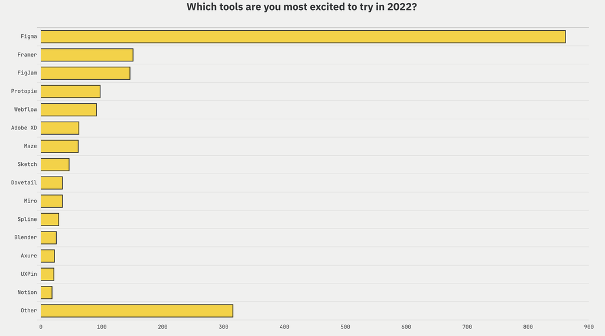

## Trends a few years later

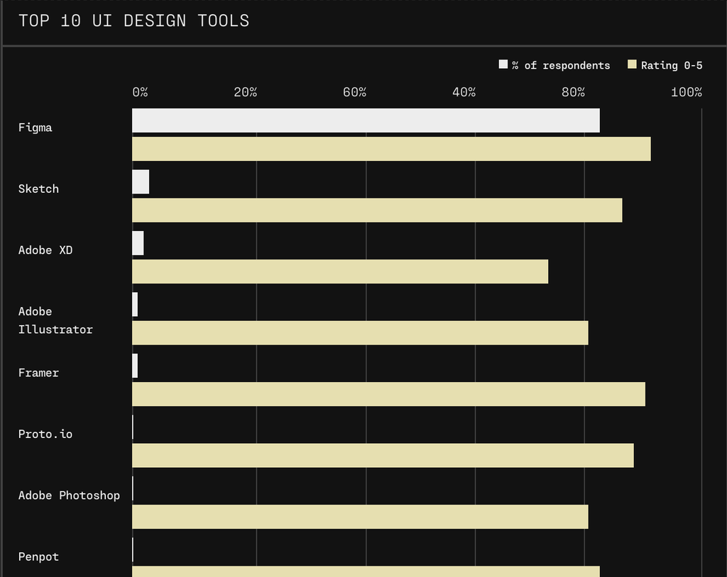

## Figma’s IPO

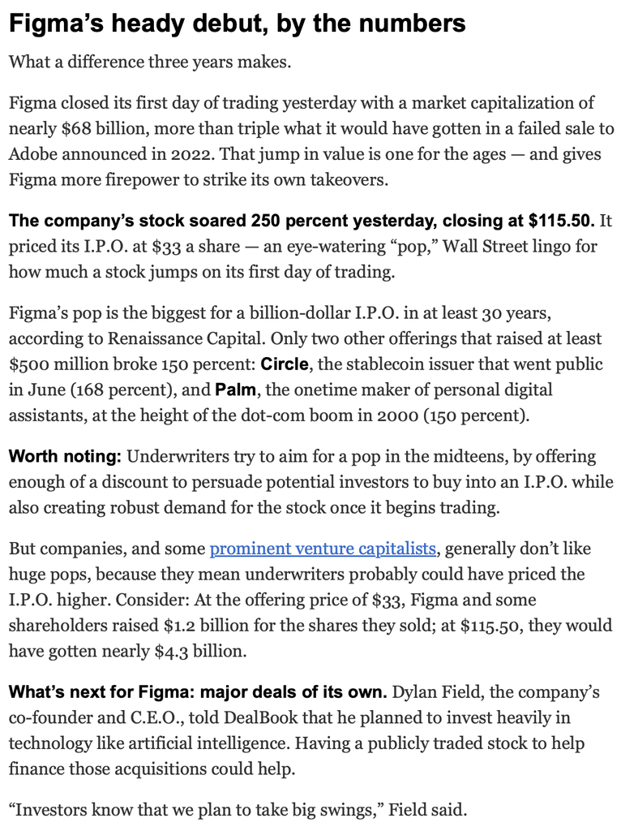

## Figma’s stock price

[figure not shown]

## Wikipedia

I use Wikipedia as a reference for many topics. For instance, the Wikipedia entry on HSV color space provides a good introduction to terms about color. Wikipedia URLs have a format so that if I refer to the entry on HSV color space, you may assume that the URL (for the English language version) is HSV_color_space. Wikipedia remains controversial among many academicians.

A historical resource for HCI literature may be found at [hcibib](http://www.hcibib.org). You may find it helpful for some of your work.

# Being the center of the universe

## Indian Bus Example

[figure not shown]

# END

# References

Arnheim, Rudolf. 1974. *Art and Visual Perception*. University of California Press.

Buxton, Bill. 2007. *Sketching User Experiences: Getting the Design Right and the Right Design*. Morgan Kaufman.

Krug, Steve. 2005. *Don’t Make Me Think: A Common Sense Approach to the Web (2nd Edition)*. New Riders Publishing.

Norman, Donald A. 2005. *Emotional Design: Why We Love (or Hate) Everyday Things*. Basic Books.

Norman, Donald A. 2013. *The Design of Everyday Things, 2nd Edition*. Basic Books.

Raskin, Jef. 2000. *The Humane Interface: New Directions for Designing Interactive Systems*. Addison-Wesley Professional.

Rosenfeld, Louis, Peter Morville, and Jorge Arango. 2015. *Information Architecture: For the Web and Beyond*. 4th ed. O’Reilly Media.

Tufte, Edward R. 2001. *The Visual Display of Quantitative Information*. Graphics Press.

# Colophon

This slideshow was produced using `quarto`

Fonts are *Fira Sans*, *Fira Sans Light*, and *Victor Mono Nerd Font*

Math is set in *Fira Math* via *MathJax 4*